# Detecting dispersion problems in GLMMs

Melina de Souza Leite & Florian Hartig

melina.souza-leite@ur.de

[University of Regensburg](https://www.uni-regensburg.de/biologie-vorklinische-medizin/forschen/arbeitsgruppen/ag-hartig)

## Replicability crisis in Ecology too?

- High **false positive rates** (type I error) in Ecological studies
- A non-intentional cause is **failing in checking model’s assumptions**
- Researchers **don’t check models** -> higher chances of false conclusions
- Few tools for **model diagnostics** of GLMs, GLMMs.

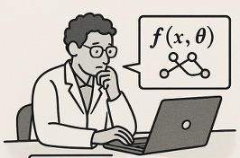

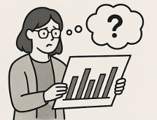

**Can you trust your model?**

## OVERDispersion problems

When data has **more variability than expected** by the model (GLM/GLMM)

**OVERDISPERSION**

- Too small standard error / confidence intervals
- Larger chance of **false positive** results
- Much more common than previously thought

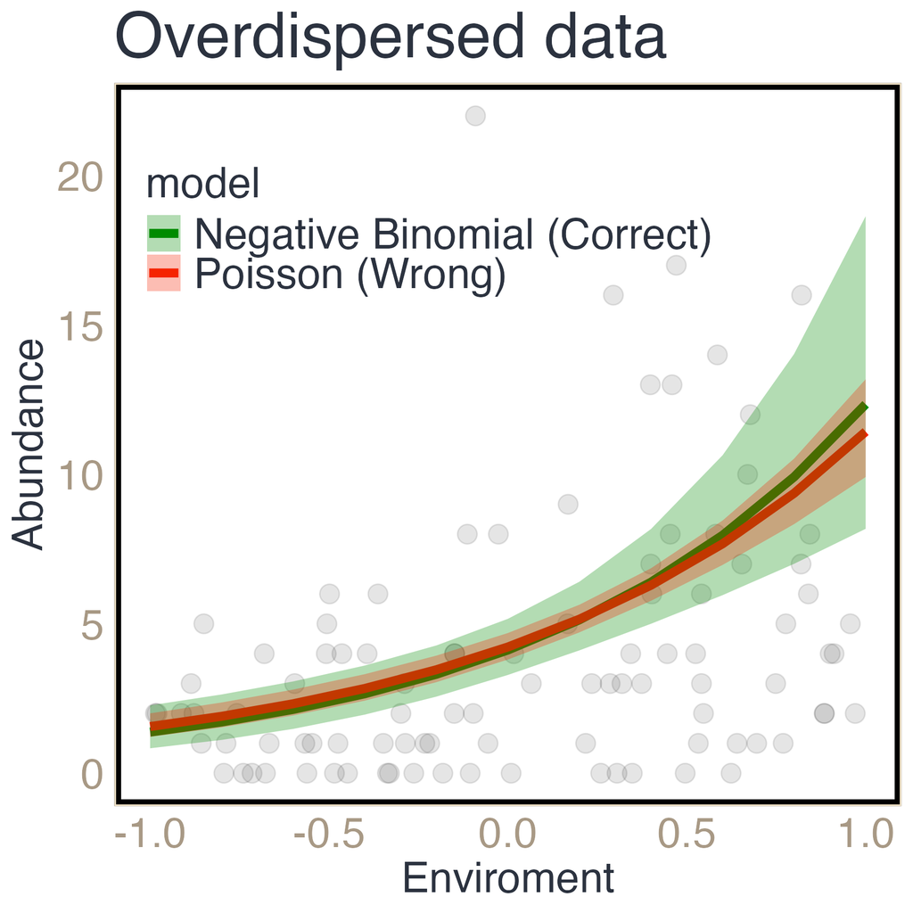

## GOALS

- Aware ecologists of dispersion problems in GLMs/GLMMs
- Identify and describe the 3 main causes by using model diagnostics tools with the `DHARMa` R package
- Show some modeling solutions for these causes, with the `glmmTMB` R package

Detecting dispersion problems with `DHARMa`

## Residual diagnostics with `DHARMa`

- Scaled quantile residuals -> Simulating from the model
- Residuals between 0 and 1 for ANY model complexity or distribution
- Interpreted the SAME way:

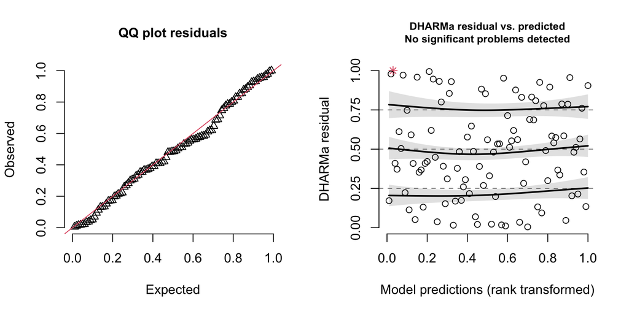

## Detecting overdispersion

Wrong model

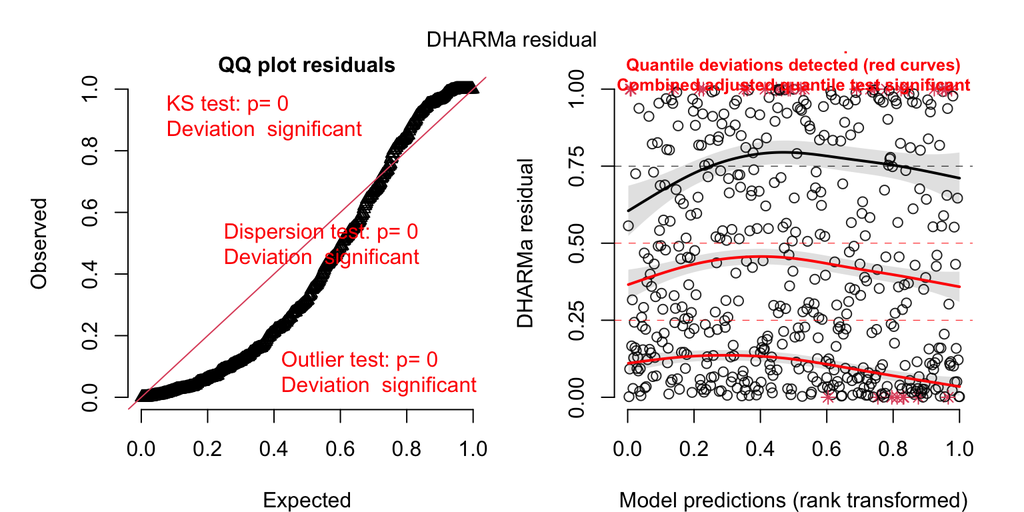

```r
m <- glmmTMB(Abundance ~ Environment + (1|group),
        family = poisson(), data = data)
res <- simulateResiduals(m)
plot(res)
testDispersion(res)
```

Dispersion = 5.19, p-value = 0.

## Detecting overdispersion

Wrong model

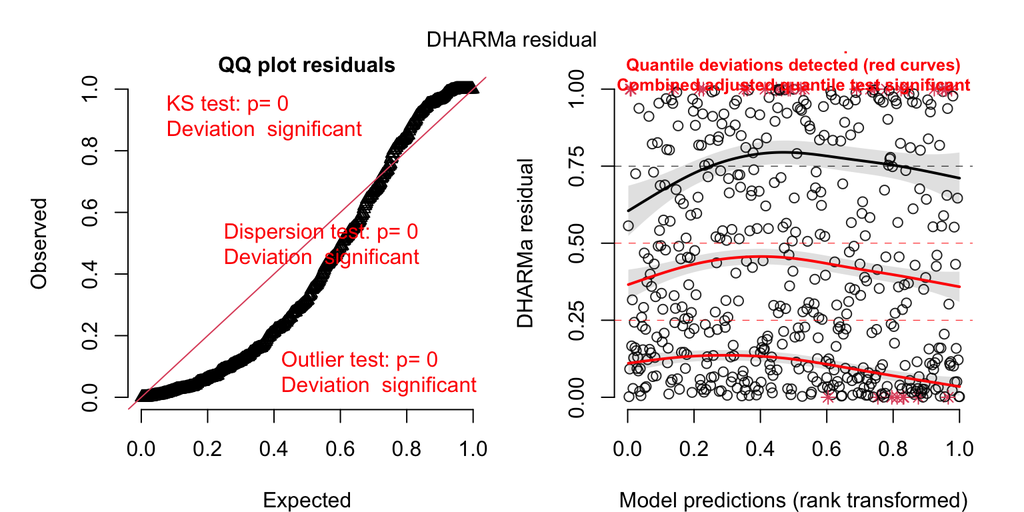

```r
m <- glmmTMB(Abundance ~ Environment + (1|group),
        family = poisson(), data = data)
res <- simulateResiduals(m)
plot(res)
testDispersion(res)
```

Dispersion = 5.19, p-value = 0.

Solution

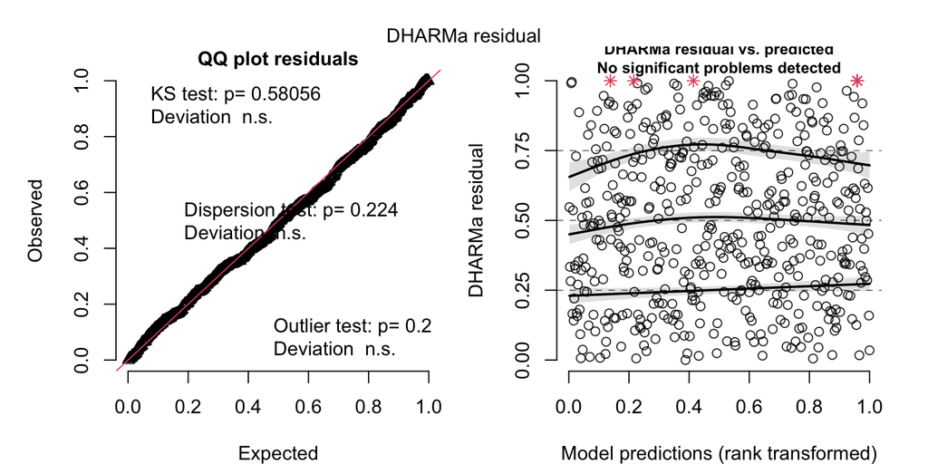

```r
m <- glmmTMB(Abundance ~ Environment + (1|group),
        family = nbinom2(), data = data)
res <- simulateResiduals(m)
plot(res)
testDispersion(res)
```

Dispersion = 1.19, p-value = 0.224.

## Another overdispersion problem

What if…

the variability in the data increases/decreases with a specific variable?

**Heteroscedasticity**

## Detecting heteroscedasticity

Wrong model

```r
m <- glmmTMB(Abundance ~ Environment + (1|group),
        family = poisson(), data = data)
res <- simulateResiduals(m)
plotResiduals(res, form = data$Environment1,
              absoluteDeviation = T)
testDispersion(res)
```

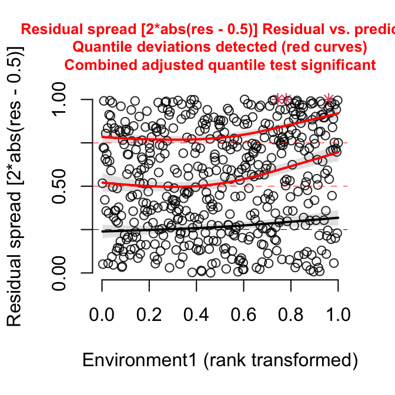

Dispersion = 1.9, p-value = 0.

## Detecting heteroscedasticity

Wrong model

```r
m <- glmmTMB(Abundance ~ Environment + (1|group),
        family = poisson(), data = data)
res <- simulateResiduals(m)
plotResiduals(res, form = data$Environment1,
              absoluteDeviation = T)
testDispersion(res)
```

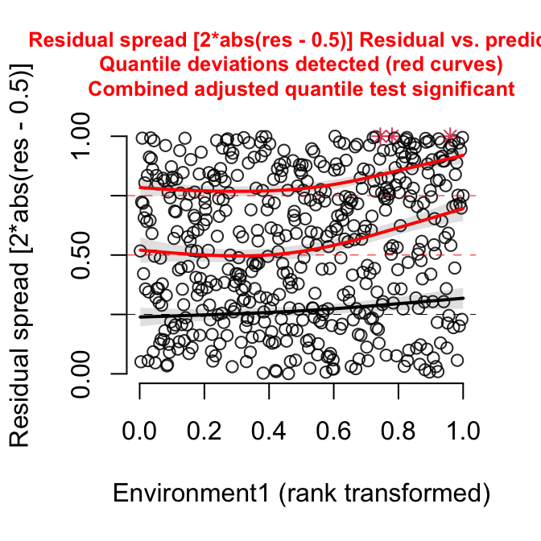

Dispersion = 1.9, p-value = 0.

Solution

```r
m <- glmmTMB(Abundance ~ Environment + (1|group),
        dispformula = ~ Environment, # dispersion formula
        family = nbinom2(), data = data) # negative binomial
res <- simulateResiduals(m)
plotResiduals(res, form = data$Environment1,
              absoluteDeviation = T)
testDispersion(res)
```

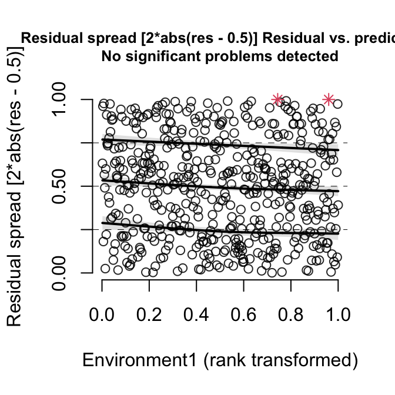

Dispersion = 1.11, p-value = 0.44.

## What if…

You have more zeros than expected by the model??

**Zero-inflation**

## Detecting zero-inflation

Wrong model

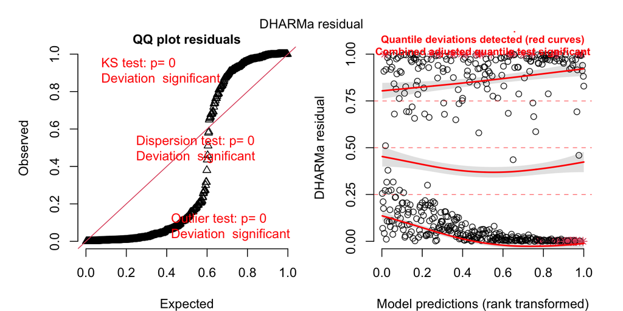

```r
m <- glmmTMB(Abundance ~ Environment + (1|group),
        family = poisson(), data = data)
res <- simulateResiduals(m)
plot(res)
testZeroInflation(res)
```

Zero-inflation = 5.16, p-value = 0.

## Detecting zero-inflation

Wrong model

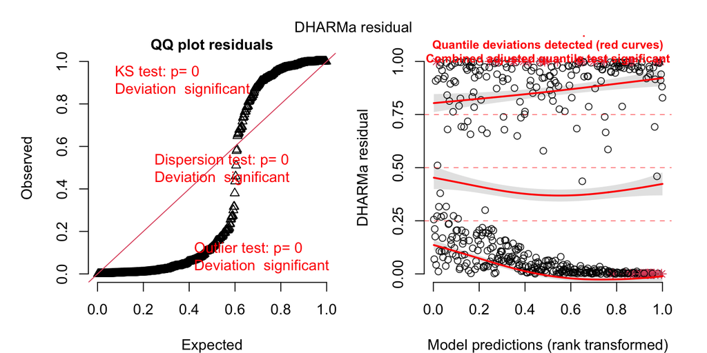

```r
m <- glmmTMB(Abundance ~ Environment + (1|group),
        family = poisson(), data = data)
res <- simulateResiduals(m)
plot(res)
testZeroInflation(res)
```

Zero-inflation = 5.16, p-value = 0.

Solution

```r
m <- glmmTMB(Abundance ~ Environment + (1|group),
        ziformula = ~ 1,  # zero-inflation formula
        family = poisson(), data = data)
res <- simulateResiduals(m)
plotResiduals(res)
testZeroInflation(res)
```

[figure not shown]

Zero-inflation = 1, p-value = 1.

## 3 causes of dispersion problems

**“Real” overdispersion:**

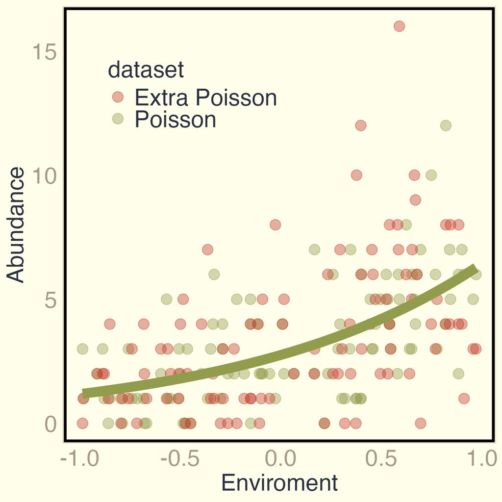

Abundances vary more that expected by the model, in general.

**Heteroscedasticity:**

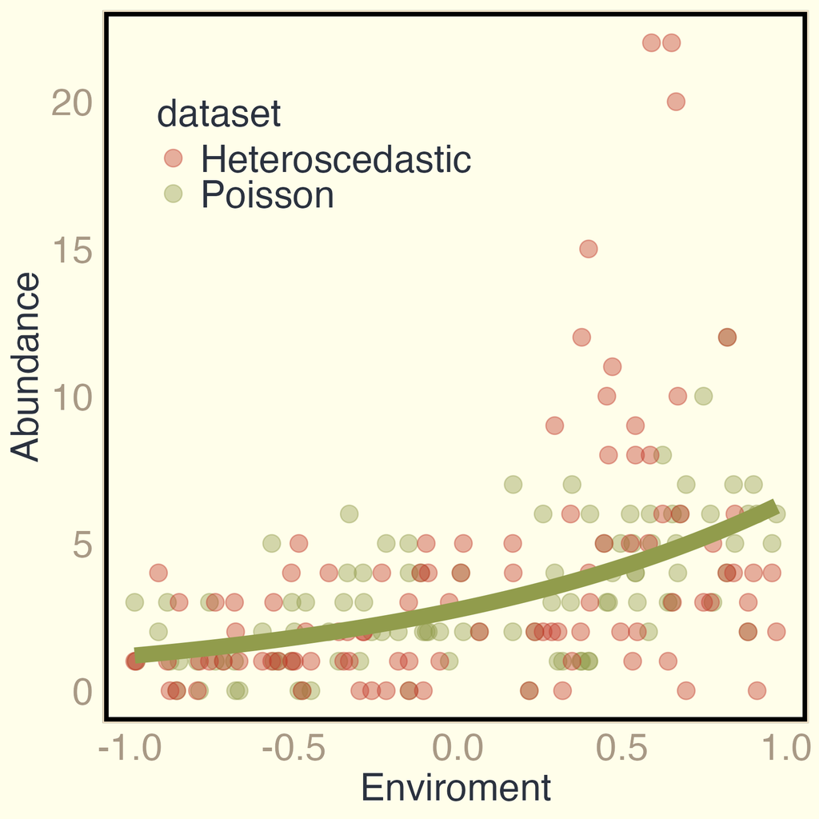

Abundances variation increases with the environmental gradient.

**Zero-inflation:**

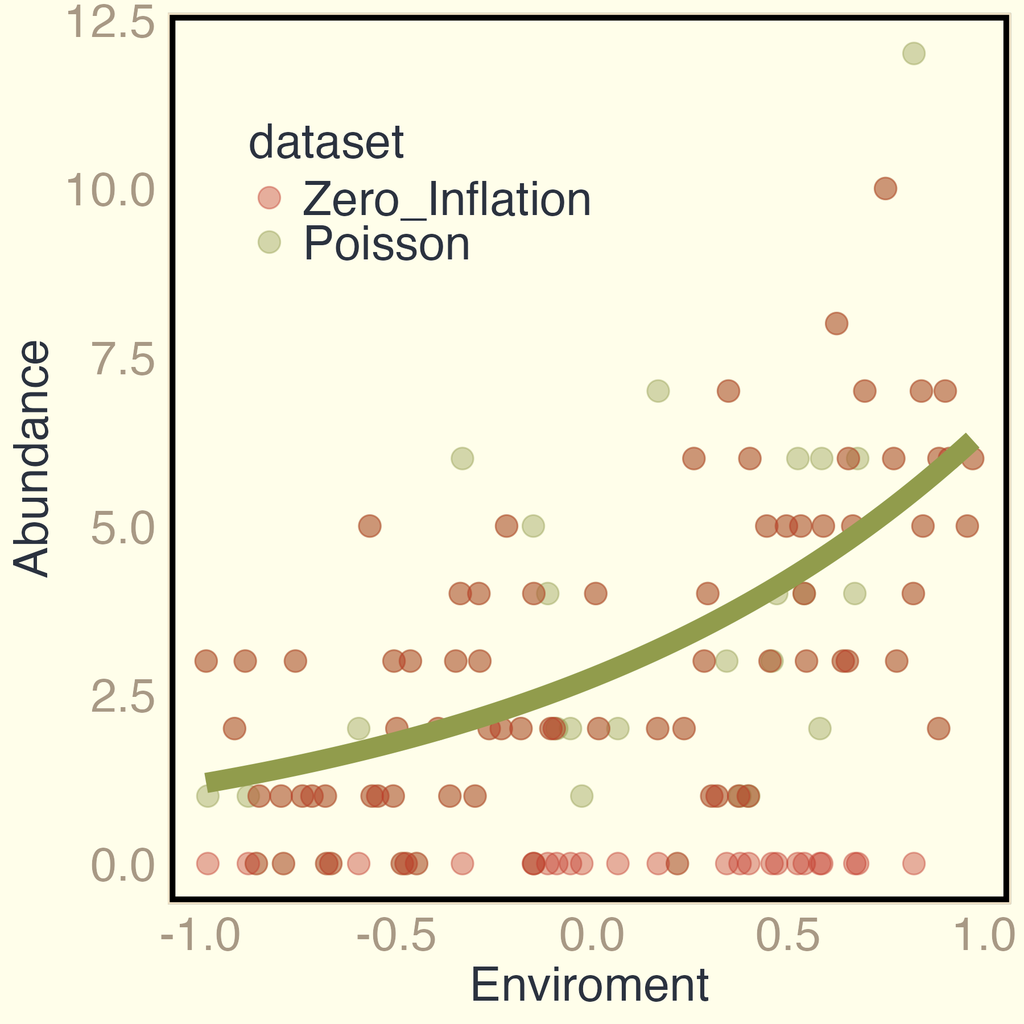

More zero abundances than expected by the model.

## Detecting dispersion problems

- Residual patterns alone will not tell you which is the cause of overdispersion. E.g.:
  - ‘Real’ overdispersion will show significant test for zero-inflation, and vice-versa.
  - ‘Real’ overdispersion and zero-inflation may have significant heteroscedasticity.
- Additional check: fit models addressing the potential problems and compare their fit (e.g. AIC, LRT) and residuals diagnostics.

`DHARMa` + `glmmTMB`

## Conclusion

- There are many causes of dispersion problems in GLMMs. To ignore it may lead fo false conclusions
- Use `DHARMa` residuals tools to detect them
- Address the problem with adequate models, e.g, `glmmTMB`

**Can you trust your model, now?**

## Take-home message

- Models should ALWAYS be checked: residual diagnostics!
- Avoid an oversimplistic view of dispersion problems
- Detecting and addressing the causes of dispersion problems may also be informative for your system/data.

Comming soon:

Leite et al. *in prep.* **Dispersion tests in GLMMs: a methods comparison and practical guide.**

Thank you!

[figure not shown]

Vielen Dank!

Thanks to Max Pichler and the Theoretical Ecology Lab group